# Multiple Linear Regression (MLR) vs Random Forest Regression Model

## We will look at how the CPI prices are affected by different energy prices

```python
import pandas as pd
import numpy as np
CPI = pd.read_excel("datasets/Energy-CPI.xlsx", sheet_name="CPI") #Open the file
```

Here we are opening the CPI and energy data into a Pandas DataFrame. We will use this DataFrame to train our models.

```python
CPI.info()
```

```
<class 'pandas.core.frame.DataFrame'>
RangeIndex: 400 entries, 0 to 399
Data columns (total 9 columns):
 #   Column              Non-Null Count  Dtype
---  ------              --------------  -----
 0   CPI                 400 non-null    float64
 1   Solid Fuels         400 non-null    float64
 2   Gas                 400 non-null    float64
 3   Electricity         400 non-null    float64
 4   Liquid Fuels        400 non-null    float64
 5   Motor fuel and oil  400 non-null    float64
 6   Unnamed: 6          0 non-null      float64
 7   Unnamed: 7          0 non-null      float64
 8   Unnamed: 8          1 non-null      object
dtypes: float64(8), object(1)
memory usage: 28.2+ KB
```

info() is a method that provides us with useful information on the DataFrame content. What I notice here is that there is a lot of null data in columns 6 to 8. It is important to remove or replace the null data before training the models.

```python
CPI=CPI.dropna(axis=1)
CPI.head()
```

|  | CPI | Solid Fuels | Gas | Electricity | Liquid Fuels | Motor fuel and oil |
| --- | --- | --- | --- | --- | --- | --- |
| 0 | 53.637 | 37.003405 | 36.411609 | 49.039693 | 35.077678 | 31.965649 |
| 1 | 53.954 | 37.003405 | 36.411609 | 49.039693 | 31.071137 | 31.870229 |
| 2 | 54.217 | 37.116913 | 36.807388 | 49.039693 | 28.863451 | 31.870229 |
| 3 | 55.211 | 37.116913 | 37.730871 | 49.551857 | 29.272281 | 34.160305 |
| 4 | 55.735 | 35.187287 | 38.654354 | 51.344430 | 28.863451 | 34.064885 |

I am opting to drop any column with a null value. I've looked at the data and the info output above, and I am only interested in columns 0 to 5 (which do not have any null values).

If these columns contained some null values then I could either replace the values (by the mean or some other metric) or I could remove those rows. The decision would depend on the amount of null values present, the importance of the missing data and how easy we could estimate the missing data accurately.

head() function gives us a brief outlook on what the data looks like.

```python
corr_matrix = CPI.corr()
corr_matrix["CPI"].sort_values(ascending=False)
```

```
CPI                   1.000000
Solid Fuels           0.980760
Motor fuel and oil    0.943426
Electricity           0.922629
Gas                   0.907724
Liquid Fuels          0.853407
Name: CPI, dtype: float64
```

[output not shown]

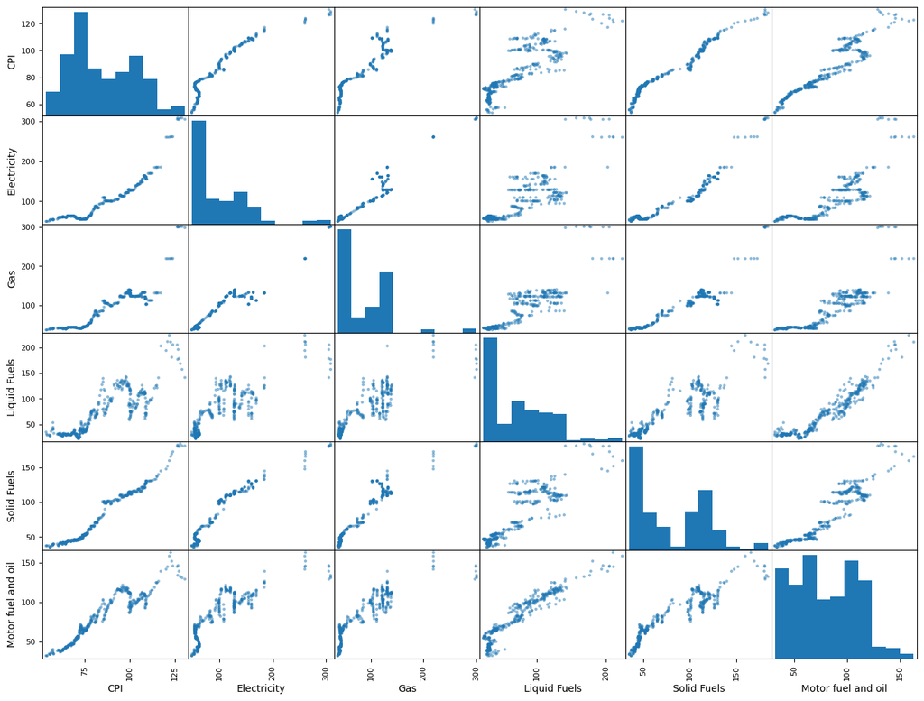

```python
from pandas.plotting import scatter_matrix
attributes = ["CPI", "Electricity", "Gas",
"Liquid Fuels", "Solid Fuels", "Motor fuel and oil" ]
scatter_matrix(CPI[attributes], figsize=(16, 12))
```

It's useful to plot the data to see if there is any non-linear relationship within the data. Correlation only shows us a measure of the linear aspect between the variables, so by visualising the data we can see if there are any non-linear relationships. It is also good to see the distribution of each variable, this can be seen in the diagonal plot.

From the above plot, we can see why the correlation between the CPI and Liquid fuels is the lowest, there is a lot of randomness.

CPI and electricity could be better modelled by a logarithmic function as the scatter plot seems to trail off for large electricity values. But the data is very sporadic and there is a lot of missing data for large electricity values so it is hard to say if the data we have is a good representation, more data is needed.

```python
y = CPI["CPI"]
X = CPI.drop(columns = ["CPI"])
```

We split the data into X and y for training purposes.

## Multiple Linear Regression

```python
import statsmodels.api as sm
from sklearn.model_selection import train_test_split
from sklearn.metrics import mean_squared_error
X_linear = sm.add_constant(X)
X_train, X_test, y_train, y_test = train_test_split(X_linear, y, test_size = 0.2, random_state = 19)
mod = sm.OLS(y_train, X_train)
res = mod.fit()
print(res.summary())
```

```
                            OLS Regression Results
==============================================================================
Dep. Variable:                    CPI   R-squared:                       0.989
Model:                            OLS   Adj. R-squared:                  0.989
Method:                 Least Squares   F-statistic:                     5540.
Date:                Sun, 13 Aug 2023   Prob (F-statistic):          8.78e-304
Time:                        16:43:45   Log-Likelihood:                -650.05
No. Observations:                 320   AIC:                             1312.
Df Residuals:                     314   BIC:                             1335.
Df Model:                           5
Covariance Type:            nonrobust
======================================================================================
                         coef    std err          t      P>|t|      [0.025      0.975]
--------------------------------------------------------------------------------------
const                 36.9110      0.488     75.656      0.000      35.951      37.871
Solid Fuels            0.2548      0.016     16.379      0.000       0.224       0.285
Gas                   -0.0672      0.009     -7.777      0.000      -0.084      -0.050
Electricity            0.1231      0.008     14.891      0.000       0.107       0.139
Liquid Fuels          -0.1611      0.009    -18.049      0.000      -0.179      -0.144
Motor fuel and oil     0.4087      0.018     22.936      0.000       0.374       0.444
==============================================================================
Omnibus:                       32.175   Durbin-Watson:                   2.103
Prob(Omnibus):                  0.000   Jarque-Bera (JB):               45.546
Skew:                          -0.682   Prob(JB):                     1.29e-10
Kurtosis:                       4.247   Cond. No.                         980.
==============================================================================

Notes:
[1] Standard Errors assume that the covariance matrix of the errors is correctly specified.
```

We use train_test_split() to split our data for our model. 80% of the data will be used for training and then we will test our model with 20% unseen test data. We use a fixed random state across both the MLR and random forest model to keep the training and testing data the same so we can then fairly compare the models.

There are some interesting statistics in the OLS regression results above: The R-squared value is a measure of how good our model is to our data. A score of 0.989 signifies that 98.9% of the data can be explained by our model. This demonstrates that this is a good model for our data. The p values ("P > |t|" in the chart) show the significance of the null hypothesis. A low p value means that we should reject the null hypothesis (the null hypothesis is that the coefficient of the respective variable is 0 and therefore should not be in our model), in this case all p values are 0.000 and therefore there is significant evidence that all variables are necessary in our model. We can write our model in the form of y = bx + c where c is the constant, b is the coefficient row vector, x is the independent variables column vector and y is dependent vector. The equation of our model is y = 36.91 + 0.25**Solid Fuels** - 0.07**Gas** + 0.12**Electricity** - 0.16**Liquid Fuels** + 0.41**Motor fuel and oil** (2dp)

```python
y_pred = res.predict(X_test)
rmse = float(format(np.sqrt(mean_squared_error(y_test, y_pred)), '.3f'))
print("\nRMSE: ", rmse)
```

```
RMSE:  1.977
```

We now compare the predicted values from our model with the true test values. We calculate the Root Mean Square Error (RMSE) and we will use this metric to see what model performs the best.

## Random Forest Regression

```python
from sklearn.ensemble import RandomForestRegressor
```

```python
X_train, X_test, y_train, y_test = train_test_split(X, y, test_size = 0.2, random_state = 19)
```

```python
# Initializing the Random Forest Regression model with 10 decision trees
model = RandomForestRegressor(n_estimators = 10, random_state = 0)

# Fitting the Random Forest Regression model to the data
model.fit(X_train, y_train)
```

```
RandomForestRegressor(n_estimators=10, random_state=0)
```

```python
# Predicting the target values of the test set
y_pred = model.predict(X_test)

# RMSE (Root Mean Square Error)
rmse = float(format(np.sqrt(mean_squared_error(y_test, y_pred)), '.3f'))
print("\nRMSE: ", rmse)
```

```
RMSE:  0.457
```

The RMSE for the random forest model is less than the MLR model, therefore we can conclude that in this scenario the random forest model is better. The benefit of the MLR model is that we can write the model down as an equation and see the weights (coefficients) of each independent variable. The benefit of the random forest regression model is that it looks deeper into patterns and relationships between the variables. It's a strong model out of the box but there is no equation to see how the independent variables are used in calculating the dependent variables.